# HW 6

Jillian Egland

2023-03-19

# Uploading data

```r
data(tips, package="reshape2")
```

# Question 2

2. How many parties did the waiter serve? What type are the variables that he collected? Show your code.
   - 244 parties
   - double (decimals), factor, integer

```r
nrow(tips)
```

```
## [1] 244
```

```r
head(tips)
```

```
##   total_bill  tip    sex smoker day   time size
## 1      16.99 1.01 Female     No Sun Dinner    2
## 2      10.34 1.66   Male     No Sun Dinner    3
## 3      21.01 3.50   Male     No Sun Dinner    3
## 4      23.68 3.31   Male     No Sun Dinner    2
## 5      24.59 3.61 Female     No Sun Dinner    4
## 6      25.29 4.71   Male     No Sun Dinner    4
```

# Question 3

3. Create a new variable size.factor which translates the variable size to a factor. Should size be a factor or a numerical variable? Give your reasoning.
   - size should be a factor because you can’t get a size that is a decimal; it isn’t a continuous integer. There are levels of sizes.

```r
tips$size.factor = as.factor(tips$size)
head(tips)
```

```
##   total_bill  tip    sex smoker day   time size size.factor
## 1      16.99 1.01 Female     No Sun Dinner    2           2
## 2      10.34 1.66   Male     No Sun Dinner    3           3
## 3      21.01 3.50   Male     No Sun Dinner    3           3
## 4      23.68 3.31   Male     No Sun Dinner    2           2
## 5      24.59 3.61 Female     No Sun Dinner    4           4
## 6      25.29 4.71   Male     No Sun Dinner    4           4
```

# Question 4

4. How does the tipping amount (tip) depend on the overall bill (total_bill)? Use the ggplot2 package to show a chart, describe the relationship in words. Describe at least two types of anomalies in the plot. What do they mean?
   - moderate, positive, linear relationship between overal bill and tipping amount
   - there is a point at (8ish, 5.1ish) that is above the general shape, this means that the person tipped a higher rate than other people who paid a similar amount for their meal
   - there are points high in the top right corner of the graph, these points mean that these people paid more and tipped more, mostly following the shape

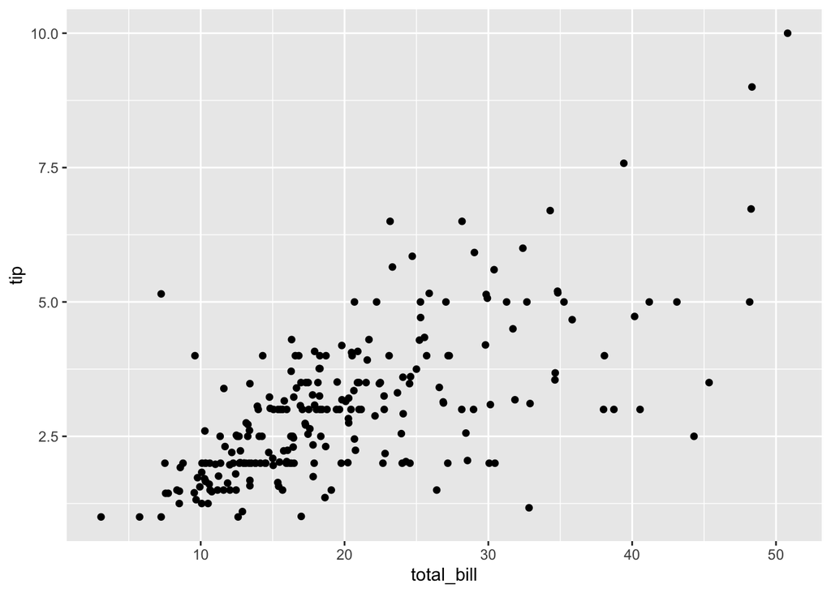

```r
library(ggplot2)
ggplot(tips, aes(x=total_bill, y=tip)) + geom_point()
```

# Question 5

```r
tips$tiprate = tips$total_bill/tips$tip
head(tips)
```

```
##   total_bill  tip    sex smoker day   time size size.factor   tiprate
## 1      16.99 1.01 Female     No Sun Dinner    2           2 16.821782
## 2      10.34 1.66   Male     No Sun Dinner    3           3  6.228916
## 3      21.01 3.50   Male     No Sun Dinner    3           3  6.002857
## 4      23.68 3.31   Male     No Sun Dinner    2           2  7.154079
## 5      24.59 3.61 Female     No Sun Dinner    4           4  6.811634
## 6      25.29 4.71   Male     No Sun Dinner    4           4  5.369427
```

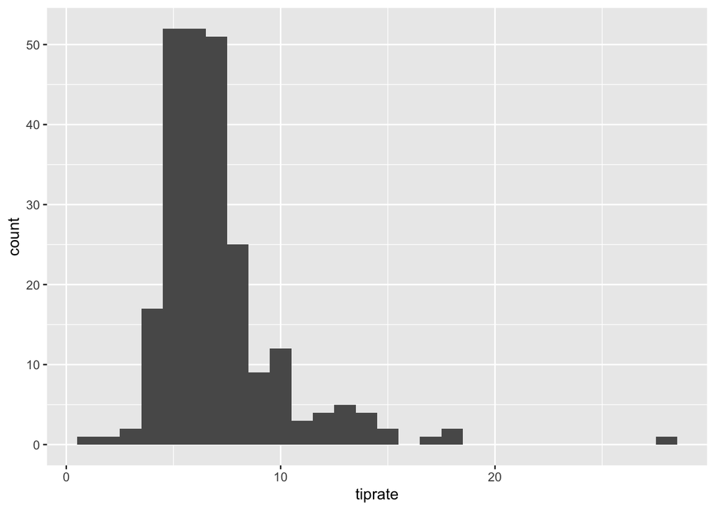

```r
ggplot(tips, aes(x=tiprate)) + geom_histogram(binwidth=1)
```

```r
# max tips
max(tips$tiprate)
```

```
## [1] 28.05983
```

```r
max_tipper = dplyr::filter(tips, tiprate==max(tips$tiprate))
max_tipper
```

```
##     total_bill  tip  sex smoker day   time size size.factor  tiprate
## 238      32.83 1.17 Male    Yes Sat Dinner    2           2 28.05983
```

```r
# min tips
min(tips$tiprate)
```

```
## [1] 1.407767
```

```r
min_tipper = dplyr::filter(tips, tiprate==min(tips$tiprate))
min_tipper
```

```
##     total_bill  tip  sex smoker day   time size size.factor  tiprate
## 173       7.25 5.15 Male    Yes Sun Dinner    2           2 1.407767
```

```r
# average tips
mean(tips$tiprate)
```

```
## [1] 7.048932
```

# Question 6

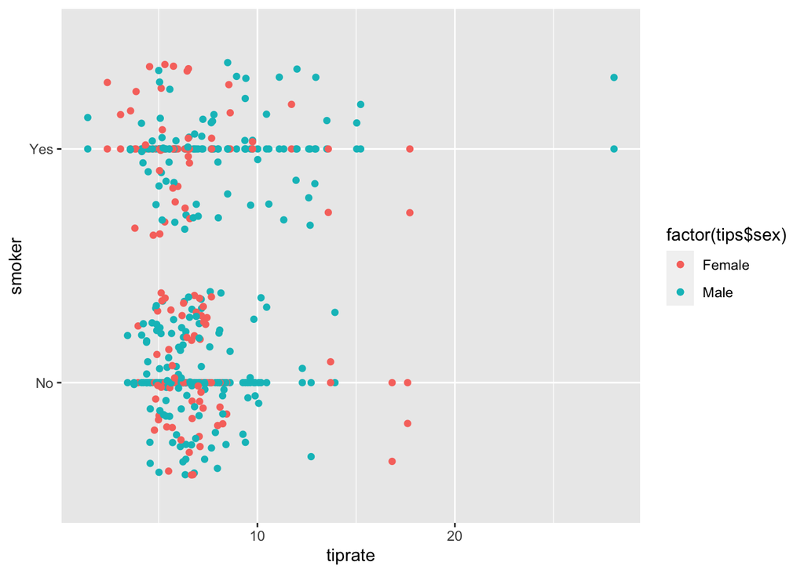

```r
library(ggmosaic)
#ggplot(data = tips)  + geom_mosaic(aes(x = product(sex, smoker)) )
ggplot(tips, aes(x=tiprate, y=smoker, color=factor(tips$sex))) + geom_point() + geom_jitter()
```

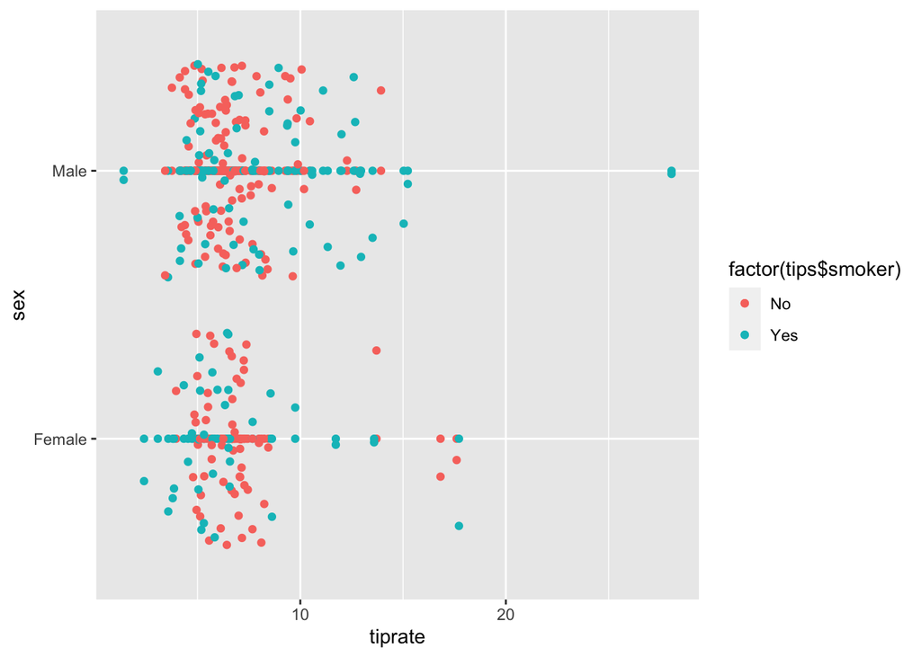

```r
ggplot(tips, aes(x=tiprate, y=sex, color=factor(tips$smoker))) + geom_point() + geom_jitter()
```

# Question 7

7. Use ggplot2 to find a graphical summary of the relationship between day of the week and gender of the person paying the bill. What can you say about this relationship?
   - as the weekend continues, the percentage of males paying for dinner increases

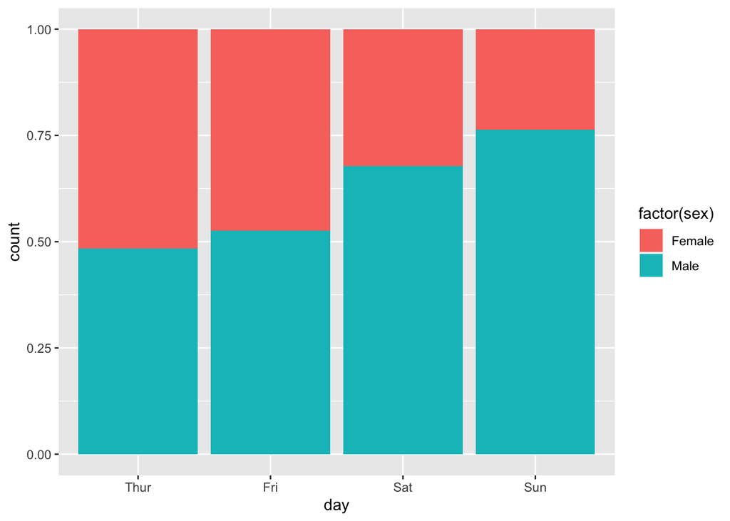

```r
tips$day = factor(tips$day, levels=c("Thur", "Fri", "Sat", "Sun"))
ggplot(tips, aes(x = day, fill=factor(sex))) + geom_bar(position="fill")
```

# Question 8

8. Use ggplot2 to make a boxplot of the tiprate on different days. Rank the levels of day by the average of the tiprate. What can you say about this relationship?
   - Sunday has the lowest average tiprate, and Saturday has the highest
   - Saturday and Sunday also have the IQR of tip rates
   - Friday has the lowest range and no outliers , so the tip rates are very similar to each other

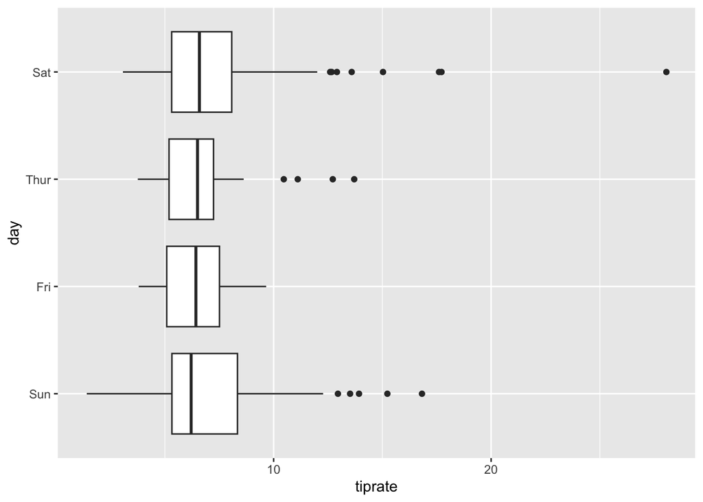

```r
tips$day = factor(tips$day, levels=c("Sun", "Fri", "Thur", "Sat"))
ggplot(tips, aes(x=day, y=tiprate)) + geom_boxplot() + coord_flip()
```